# Session 6: Probability & Simulation

Mobina Pourmoshir

2/23/2024

# Probability Distributions in R

- R provides a number of built-in functions for many probability distributions.
- For each probability distribution there are four functions associated with it. They carry the prefixes
  - `d`: stands for “density”, returning the probability density function
  - `p`: stands for “probability”, returning the cumulative distribution function;
  - `q`: stands for “quantile”, returning the inverse of the cumulative distribution function; and
  - `r`: stands for “random”, returning random numbers following the specified probability distribution.
- Below is an incomplete list of the available distributions for reference.

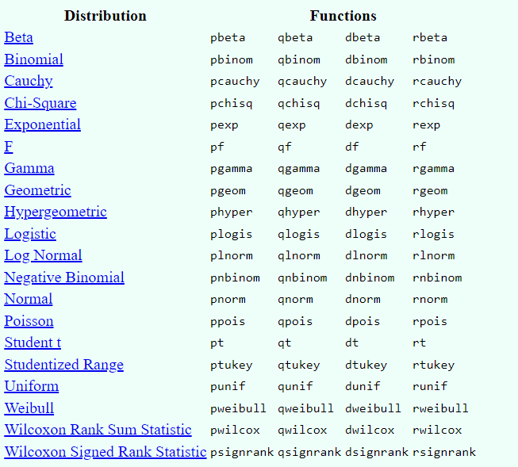

# Normal Distribution

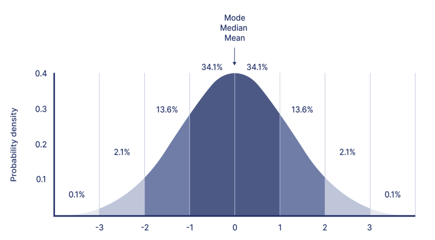

$$f(x;\mu,\sigma)= \frac{1}{\sqrt{2 \pi \sigma^2}}e^{\frac{−(x-\mu)^2}{2\sigma^2}}$$

- Next we introduce the R functions associated with the most commonly used probability distribution in Statistics: the normal distribution.
- The associated R functions are `dnorm()`, `pnorm()`, `qnorm()` and `rnorm()`.
- Type `?dnorm` in the R console for the detail of their usage.

#### `dnorm()`

- The `dnorm(x)` function returns the density of the standard normal distribution `(mean=0, standard deviation=1) at x`.
- The probability density function for the standard normal distribution is
  $$f(x)=\frac{1}{\sqrt{2 \pi}}e^{−x^2/2}$$
- Example: `dnorm(-4,4)` returns the density $f(x)$ at $x = -4,-3, -2, -1, 0, 1, 2,3 \; \textrm{and}\; 4$. We see that the distribution is symmetric about $x=0$.

```r
dnorm(-4:4)
```

```
## [1] 0.0001338302 0.0044318484 0.0539909665 0.2419707245 0.3989422804
## [6] 0.2419707245 0.0539909665 0.0044318484 0.0001338302
```

- You get the same numbers by plugging the numbers $-4:4$ to the formula of the normal curve:

```r
1/sqrt(2*pi)*exp(-(-4:4)^2/2)
```

```
## [1] 0.0001338302 0.0044318484 0.0539909665 0.2419707245 0.3989422804
## [6] 0.2419707245 0.0539909665 0.0044318484 0.0001338302
```

# Normal Distribution

- The standard normal curve can be plotted using the command

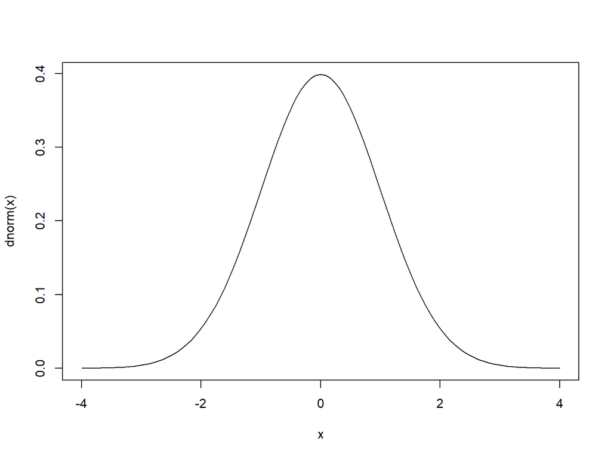

```r
curve(dnorm(x), xlim=c(-4,4))
```

- `xlim=c(-4,4)` tell `R` to plot the function in the range $-4 \le x \le 4$. (Type `?curve` to see the usage)
- The `dnorm()` function has other options that allow you to specify the mean and standard deviation of the normal distributions.(Type `?dnorm` to see the usage).
- The mathematical equation for the distribution is
  $$f(x;\mu,\sigma)= \frac{1}{\sqrt{2 \pi \sigma^2}}e^{\frac{−(x-\mu)^2}{2\sigma^2}}$$

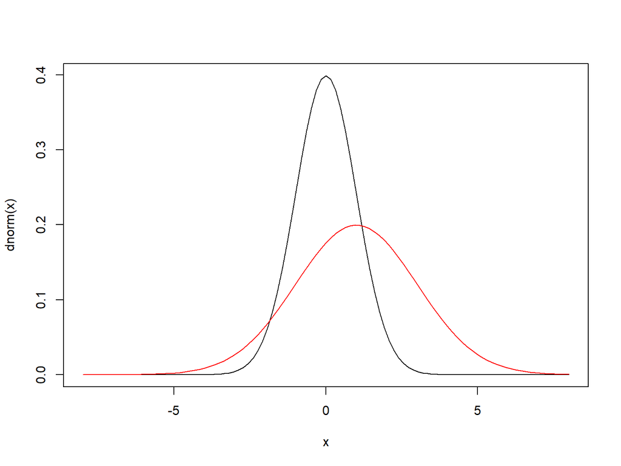

```r
curve(dnorm(x), xlim=c(-8,8))
curve(dnorm(x, mean=1, sd=2), col="red", add=TRUE)
```

- The first line in the code chunk plots the standard normal curve (**black curve**) in the range $−8\le x \le 8$.
- The second line in the code chunk plots the normal curve with mean ($\mu = 1$) and standard deviation ($\sigma=2$), with a red line specified by `col="red"`.
- The `add=TRUE` means that the plot should be added to the first plot instead of generating a new plot.

# Normal Distribution

#### `pnorm`

- The `pnorm(z)` function returns the cumulative probability of the standard normal distribution at `Z score` $z$. ($P(Z<z)$)
- That is, it’s the area under the standard normal curve to the left of z (the area of the shaded blue region in the plot below).

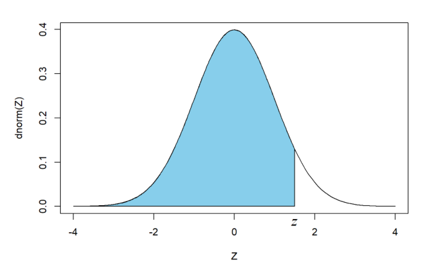

- Example,

```r
pnorm(1.65)
```

```
## [1] 0.9505285
```

- This means, the probability of getting a `Z score` smaller than $1.65$ is $0.95$ or $95\%$. (left-side tail)

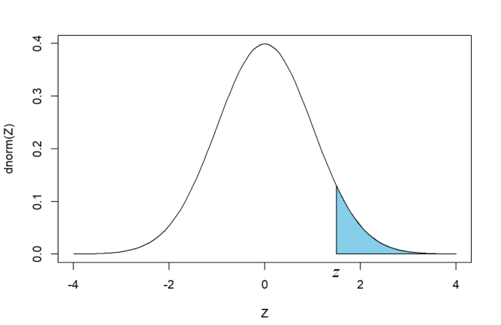

- To find the area to the right (right-side tail), especially the case when we want to find the (one-sided) p-value corresponding to a `Z score`. We consider two methods.  
1. $P(Z>z)=P(Z<-z)$.  
- Example 1) $P(Z>1.65)=P(Z<-1.65)$

```r
pnorm(-1.65)
```

```
## [1] 0.04947147
```

- Example 2) $P(Z>1.65)=1-P(Z<1.65)$

```r
1-pnorm(1.65)
```

```
## [1] 0.04947147
```

2. Use `lower.tail=FALSE` option in `pnorm()`.

```r
pnorm(1.65,lower.tail=FALSE)
```

```
## [1] 0.04947147
```

# Normal Distribution

#### `qnorm`

- The `qnorm()` function is the inverse of the `pnorm()` function: `qnorm(y)` returns the value `x` so that `pnorm(x)=y`.
- Example, the `Z score` corresponding to the $95^{th}$ percentile is

```r
qnorm(0.95)
```

```
## [1] 1.644854
```

- Interpretation: If you were to draw many samples from a standard normal distribution, you would expect that about 95% of those samples would have values less than 1.644854.
- To confirm the result is correct:

```r
pnorm( qnorm(0.95) )
```

```
## [1] 0.95
```

- The `lower.tail=FALSE` option refers to the area of the right tail like the `pnorm`.
- Example,

```r
qnorm(0.05,lower.tail=FALSE)
```

```
## [1] 1.644854
```

- This means that the `Z score` corresponding to the area of the right tail equaling 0.05 is 1.645.
- By symmetry of the normal curve (the `Z score` is the negative of the `Z score` corresponding to the area of the left tail being 0.05). It can also be obtained by the following expression;

```r
- qnorm(0.05)
```

```
## [1] 1.644854
```

# $\chi^2$ Distribution

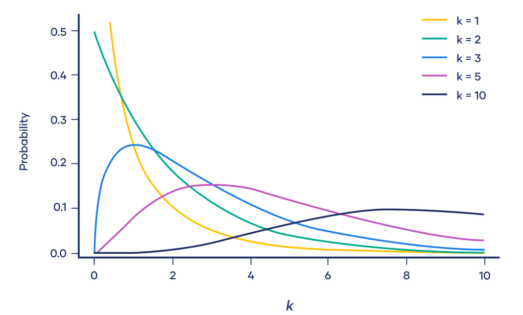

- If $X_1, X_2, \cdots, X_k$ are independent random variables and they all follow the standard normal distribution, then the random variable
  $$Q=X^2_1+X_2^2+ \cdots+ X_k^2$$
  follows the $\chi^2$ distribution with $k$ degrees of freedom.
- A $\chi^2$ distribution with $k$ degrees of freedom is constructed by the sum of the square of k independent, standard normal random variables.
- The four functions associated with the $\chi^2$ distribution are `dchisq()`, `pchisq()`, `qchisq()`, `rchisq()`.
- The usage is essentially the same as the four functions associated with the normal distribution.
- Again, use `?dchisq` to find out more information.
- The probability density function of the $\chi^2$ distribution can be found [here](https://en.wikipedia.org/wiki/Chi-squared_distribution#Probability_density_function).

# $\chi^2$ Distribution

#### `dchisq()`

- To visualize the $\chi^2$ distribution, we plot the density function using `dchisq()` at different degrees of freedom.

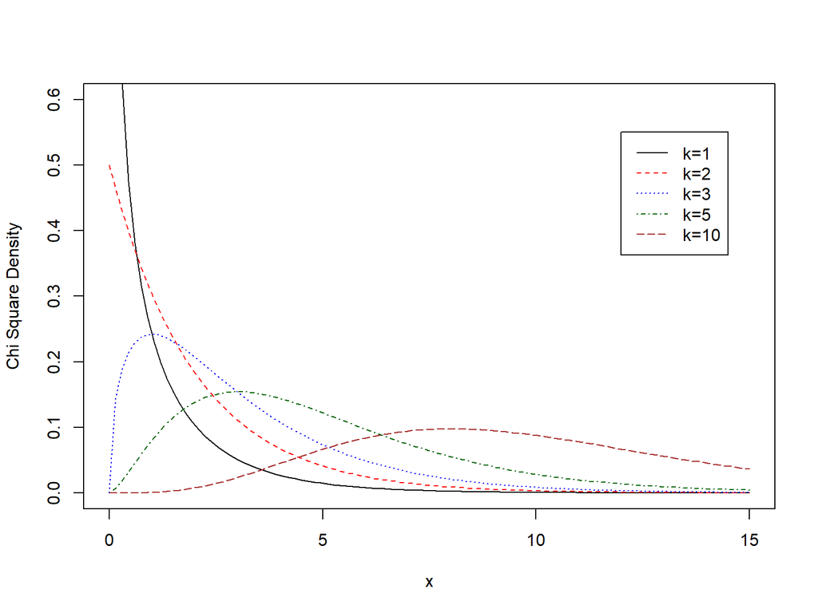

```r
curve(dchisq(x,1),xlim=c(0,15),ylim=c(0,0.6),ylab="Chi Square Density")
curve(dchisq(x,2),col="red",lty=2,add=TRUE)
curve(dchisq(x,3),col="blue",lty=3,add=TRUE)
curve(dchisq(x,5),col="dark green",lty=4,add=TRUE)
curve(dchisq(x,10),col="brown",lty=5,add=TRUE)
legend(12,0.55,c("k=1","k=2","k=3","k=5","k=10"),
       col=c("black","red","blue","dark green","brown"),lty=1:5)
```

- `dchisq()` requires at least 2 arguments. The first argument is the value of `x` we want to compute the density and the second one is the degree of freedom `k`.
- $\chi^2$ density functions with degrees of freedom k=1, 2, 3, 5 and 10 are plotted together in the plot above.
  - `ylim` is used to set the y-range of the plot;
  - `ylab` is used to change the y-axis label;
  - `lty` is used to change the line type (1=solid, 2=dashed, 3=dotted, 4=dash-dotted, 5=long-dashed);
  - `legend()` is used to display the legend.

# $\chi^2$ Distribution

#### `pchisq()`

- `pchisq(x,df)` function returns the cumulative probability $P(\chi^2 < x)$ for the $\chi^2$ distribution with `df` degrees of freedom, i.e. the area of the shaded region in the plot of the $\chi^2$ density curve below.

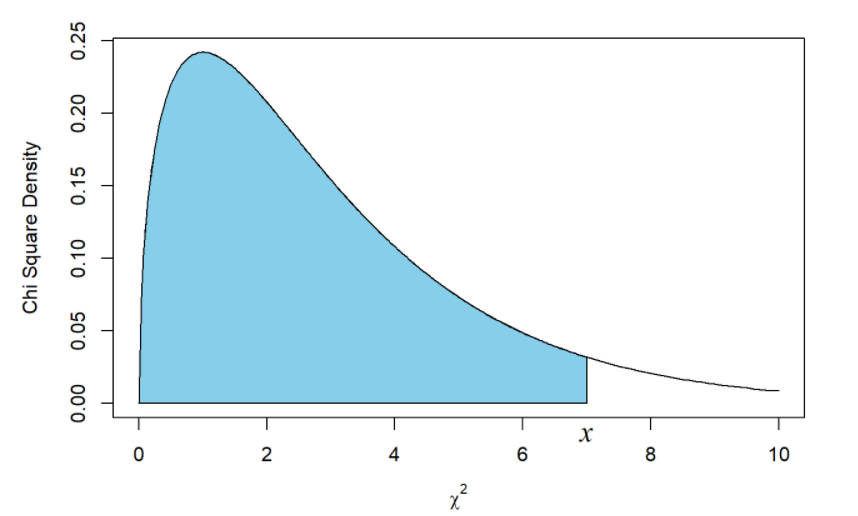

- For the p-value calculation, we usually want the area of the tail, i.e. $P(\chi^2 > x)$, the shaded region below.

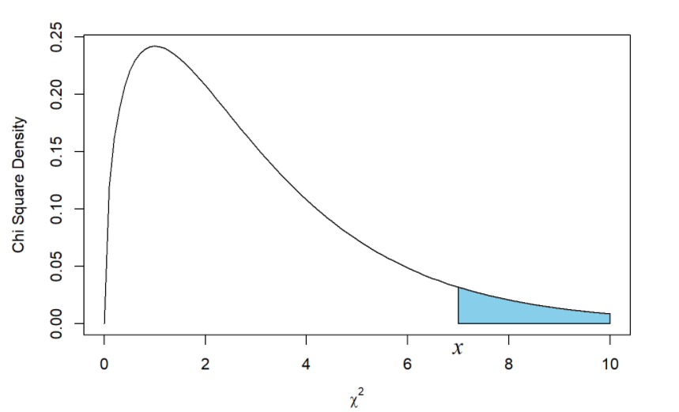

- We use `pchisq(x,df,lower.tail=FALSE)` or `1-pchisq(x,df)`.
- Example, the p-value corresponding to $\chi^2=21.78$ and $df=10$ is

```r
pchisq(21.78,10,lower.tail=FALSE)
```

```
## [1] 0.01626544
```

#### `qchisq()`

- The `qchisq()` is the inverse of `pchisq()`: if `pchisq(x)=y`, then `qchisq(y)=x`.
- Example, the $\chi^2$ value corresponding to a $5\%$ `p-value` and $df=10$ is

```r
qchisq(0.05,10,lower.tail=FALSE)
```

```
## [1] 18.30704
```

# Student’s t Distribution

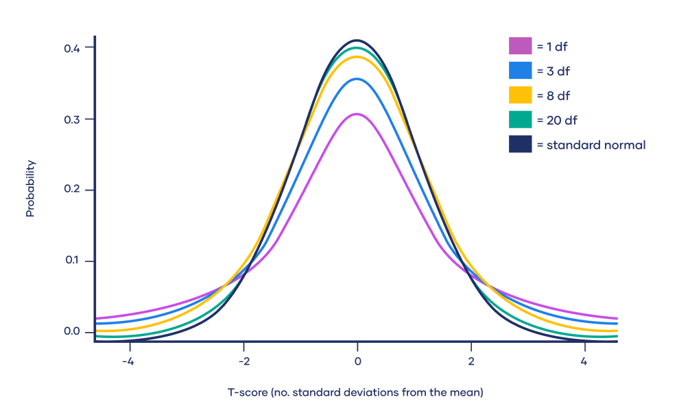

- Let $Z$ and $W$ be two independent random variables where $Z \sim N$ and $W \sim \chi^2(k)$, then the random variable
  $$T= \frac{Z}{\sqrt{W/k}}$$
  is said to follow the `t` distribution with k degrees of freedom.
- The four functions associated with the t distributions are `dt()`, `pt()`, `qt()` and `rt()`.
- The probability density function for the `t` distribution can be found [here](https://en.wikipedia.org/wiki/Student's_t-distribution#Probability_density_function) and in many textbooks.
- We generate $10^5$ random numbers following the `t` distribution with 5 `df` from the definition of the t distribution:

```r
Z <- rnorm(1e5)
W <- rchisq(1e5,5)
T <- Z/sqrt(W/5)
```

- We plot a histogram for the data:

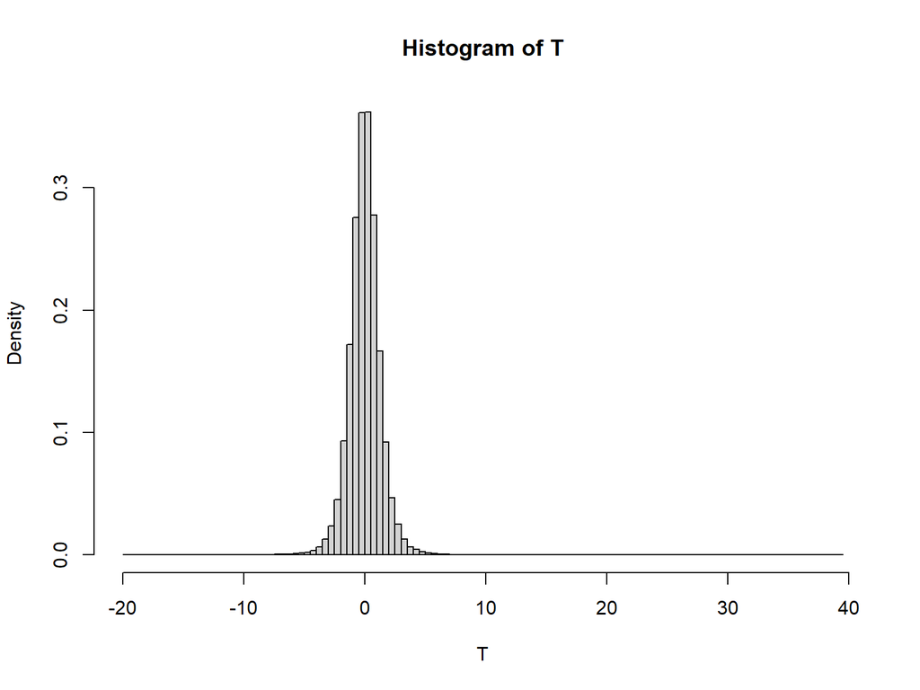

```r
hist(T,breaks=100,freq=FALSE)
```

# Student’s t Distribution

#### `dt()`

- Use the `xlim` parameter to exclude the region outside $(-5,5)$.
- We plot the `dt()` function on the same graph.

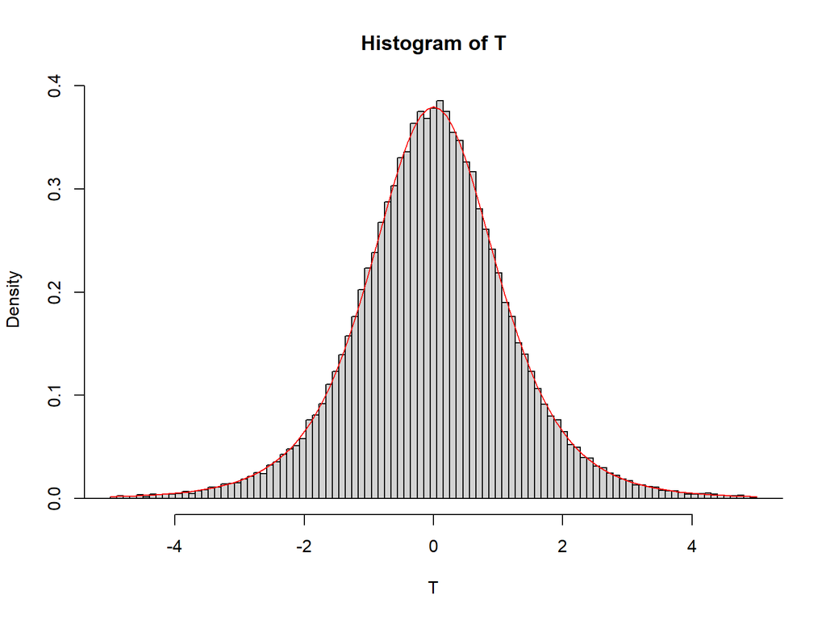

```r
hist(T, breaks=c(min(T), seq(-5,5,length.out=100), max(T)), freq=FALSE, xlim=c(-5,5))
curve(dt(x,5),col="red",add=TRUE)
```

- From above, we observe the `t` distribution is symmetric about x=0 and resembles the normal curve.
- You may recall from Stats class that the `t` distribution approaches the normal distribution when the degree of freedom $k \rightarrow \infty$.
- In general, the `t` curve falls more slowly than the normal curve at large $|x|$.
- The following code chunk plots the t curves with various degrees of freedom.

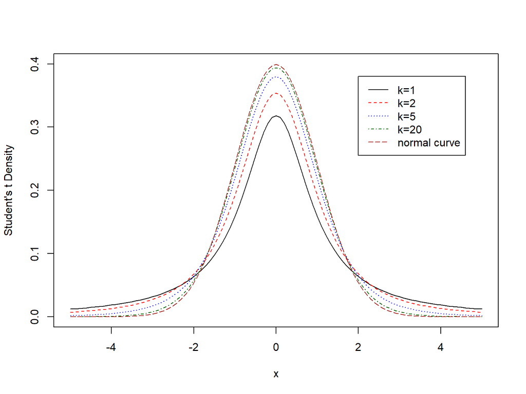

```r
curve(dt(x,1),xlim=c(-5,5),ylim=c(0,0.4),ylab="Student's t Density")
curve(dt(x,2),col="red",lty=2,add=TRUE)
curve(dt(x,5),col="blue",lty=3,add=TRUE)
curve(dt(x,20),col="dark green",lty=4,add=TRUE)
curve(dnorm(x),col="brown",lty=5,add=TRUE)
legend(2,0.38,c("k=1","k=2","k=5","k=20","normal curve"),
       col=c("black","red","blue","dark green","brown"),lty=1:5)
```

# Student’s t Distribution

#### `pt()` and `qt()`

- `pt()` and `qt()` functions are used exactly the same way as the `pchisq()` and `qchisq()` functions.
- **P-value:** The probability that a particular statistical measure, such as the mean or standard deviation, of an assumed probability distribution will be **greater than or equal to** observed results.

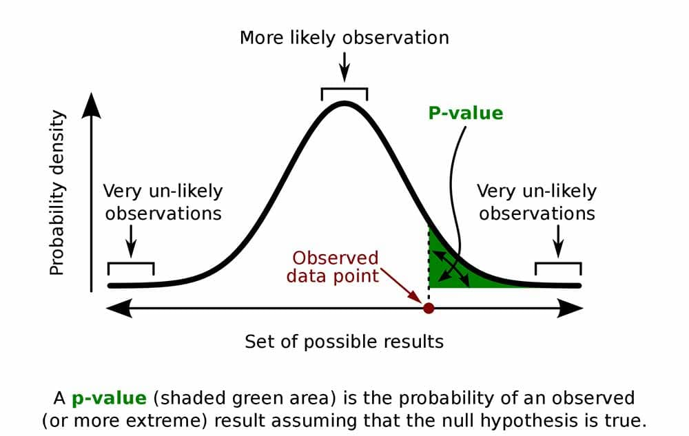

- Example, the `p-value` corresponding to $t=1.5$ and $df=4$ is

```r
pt(1.5,4,lower.tail=FALSE)
```

```
## [1] 0.104
```

- This is also equal to `pt(-1.5,4)` since the `t` curve is symmetric.
- The value of `t` corresponding to a `p-value` of $5\%$ and $df=4$ is

```r
qt(0.05,4,lower.tail=FALSE)
```

```
## [1] 2.131847
```

- This is also equal to `-qt(0.05,4)`.

```r
- qt(0.05,4)
```

```
## [1] 2.131847
```

# Simulation

#### Generating Random Numbers

- In statistics and other areas, the need to introduce randomness in processes and experiments is important.
- Simulation is therefore an important topic.
- Markov chain Monte Carlo, the bootstrap, random forests, bagging, etc. are some statistical procedure that requires random number generation or sampling during implementation.
- Sometimes you want to simulate a system and random number generators can be used to model random inputs.
- `R` comes with a set of pseuodo-random number generators that allow you to simulate from well known probability distributions like the Normal, Poisson, and binomial.
- You might have observed we skipped `rnorm()`, `rchisq()`, `rt()` earlier. These functions are used to simulate random numbers for probability distributions in `R`
- `rnorm(n, mean = 0, sd = 1)` : generates $n$ standard Normal random numbers with mean 0 and standard deviation 1.
- `rchisq(n,df)` : generates $n$ random numbers following the $\chi^2$ distribution with `df` degrees of freedom.
- `rt(n,df)` : generates $n$ random numbers following the `t` distribution with `df` degrees of freedom.

# Simulation

#### Setting the random number seed

```r
rnorm(10)
```

```
##  [1] -1.0017785  0.6663328  0.3835178 -0.4153726 -0.2316830 -1.1512483
##  [7] -0.4899375  2.3638407 -0.9956290  0.7010692
```

```r
rnorm(10)
```

```
##  [1] -1.12109692  1.08089764 -0.14250110 -0.58246592 -0.02146298 -1.20331383
##  [7] -0.42080190 -0.41233970  0.41869180  1.18181052
```

- When simulating any random numbers, we will want to be able reproduce the exact randomly generated numbers.
- Setting the random number seed with `set.seed()` ensures reproducibility of the sequence of random numbers.

```r
set.seed(107281)
y <- rnorm(10)
y
```

```
##  [1]  0.12977398 -0.93544505  0.44900614 -0.85894095  0.03539138 -0.31035867
##  [7] -1.01223948 -0.70036977 -0.92594897 -0.53929791
```

```r
z <- rnorm(10)
z
```

```
##  [1]  0.81412055 -0.65041261  0.76975912  1.46504444 -0.07391547 -0.28979138
##  [7] -1.43520277 -0.20861926 -0.44830295 -0.58084481
```

```r
set.seed(107281)
rnorm(10)
```

```
##  [1]  0.12977398 -0.93544505  0.44900614 -0.85894095  0.03539138 -0.31035867
##  [7] -1.01223948 -0.70036977 -0.92594897 -0.53929791
```

```r
set.seed(2819237)
x <- rnorm(1e6)

mean(x)
```

```
## [1] 0.0002653571
```

```r
sd(x)
```

```
## [1] 1.000039
```

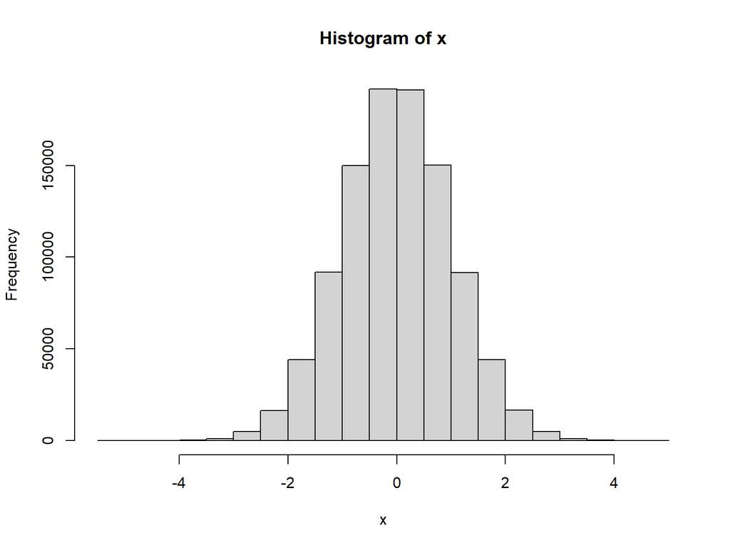

```r
hist(x)
```

# Simulation

#### Random Sampling

- The `sample()` function draws randomly from a specified set of (scalar) objects allowing you to sample from arbitrary distributions of numbers.

```r
set.seed(12345)
sample(1:10, 4)
```

```
## [1] 3 8 2 5
```

```r
sample(1:10, 4)
```

```
## [1] 8 2 6 3
```

```r
## Doesn't have to be numbers
sample(letters, 5)
```

```
## [1] "f" "g" "j" "q" "h"
```

```r
## Sample w/replacement
sample(1:10, replace = TRUE)
```

```
##  [1]  7  6  1  4  8 10  3  9  4 10
```

- Drawing samples from specific probability distributions can be done with `r` functions.
- The `sample()` function can be used to draw random samples from arbitrary vectors.
- Setting the random number generator seed via set.seed() is critical for reproducibility.